# Risk Factor Analysis

## Outcome Variable

**Outcome Variable:** haz

## Predictor Variables

**Intervention Variable:** impfloor

**Adjustment Set:**

unadjusted

## Stratifying Variables

The analysis was stratified on these variable(s):

- agecat
- studyid
- country

## Data Summary

| agecat | studyid | country | impfloor | n_cell | n |
| --- | --- | --- | --- | --- | --- |
| Birth | ki0047075b-MAL-ED | BANGLADESH | 1 | 216 | 234 |
| Birth | ki0047075b-MAL-ED | BANGLADESH | 0 | 18 | 234 |
| Birth | ki0047075b-MAL-ED | BRAZIL | 1 | 172 | 174 |
| Birth | ki0047075b-MAL-ED | BRAZIL | 0 | 2 | 174 |
| Birth | ki0047075b-MAL-ED | INDIA | 1 | 181 | 191 |
| Birth | ki0047075b-MAL-ED | INDIA | 0 | 10 | 191 |
| Birth | ki0047075b-MAL-ED | NEPAL | 1 | 66 | 164 |
| Birth | ki0047075b-MAL-ED | NEPAL | 0 | 98 | 164 |
| Birth | ki0047075b-MAL-ED | PERU | 1 | 56 | 259 |
| Birth | ki0047075b-MAL-ED | PERU | 0 | 203 | 259 |
| Birth | ki0047075b-MAL-ED | SOUTH AFRICA | 1 | 197 | 218 |
| Birth | ki0047075b-MAL-ED | SOUTH AFRICA | 0 | 21 | 218 |
| Birth | ki0047075b-MAL-ED | TANZANIA, UNITED REPUBLIC OF | 1 | 8 | 117 |
| Birth | ki0047075b-MAL-ED | TANZANIA, UNITED REPUBLIC OF | 0 | 109 | 117 |
| Birth | ki1000108-CMC-V-BCS-2002 | INDIA | 1 | 71 | 71 |
| Birth | ki1000108-CMC-V-BCS-2002 | INDIA | 0 | 0 | 71 |
| Birth | ki1000108-IRC | INDIA | 1 | 287 | 287 |
| Birth | ki1000108-IRC | INDIA | 0 | 0 | 287 |
| Birth | ki1017093-NIH-Birth | BANGLADESH | 1 | 24 | 28 |
| Birth | ki1017093-NIH-Birth | BANGLADESH | 0 | 4 | 28 |
| Birth | ki1017093c-NIH-Crypto | BANGLADESH | 1 | 21 | 27 |
| Birth | ki1017093c-NIH-Crypto | BANGLADESH | 0 | 6 | 27 |
| Birth | ki1114097-CONTENT | PERU | 1 | 2 | 2 |
| Birth | ki1114097-CONTENT | PERU | 0 | 0 | 2 |
| Birth | kiGH5241-JiVitA-3 | BANGLADESH | 1 | 1076 | 19563 |
| Birth | kiGH5241-JiVitA-3 | BANGLADESH | 0 | 18487 | 19563 |
| Birth | kiGH5241-JiVitA-4 | BANGLADESH | 1 | 71 | 822 |
| Birth | kiGH5241-JiVitA-4 | BANGLADESH | 0 | 751 | 822 |
| 6 months | ki0047075b-MAL-ED | BANGLADESH | 1 | 221 | 240 |
| 6 months | ki0047075b-MAL-ED | BANGLADESH | 0 | 19 | 240 |

[output cut: 62 more lines]

The following strata were considered:

- agecat: 24 months, studyid: ki0047075b-MAL-ED, country: BANGLADESH
- agecat: 24 months, studyid: ki0047075b-MAL-ED, country: BRAZIL
- agecat: 24 months, studyid: ki0047075b-MAL-ED, country: INDIA
- agecat: 24 months, studyid: ki0047075b-MAL-ED, country: NEPAL
- agecat: 24 months, studyid: ki0047075b-MAL-ED, country: PERU
- agecat: 24 months, studyid: ki0047075b-MAL-ED, country: SOUTH AFRICA
- agecat: 24 months, studyid: ki0047075b-MAL-ED, country: TANZANIA, UNITED REPUBLIC OF
- agecat: 24 months, studyid: ki1000108-CMC-V-BCS-2002, country: INDIA
- agecat: 24 months, studyid: ki1000108-IRC, country: INDIA
- agecat: 24 months, studyid: ki1017093-NIH-Birth, country: BANGLADESH
- agecat: 24 months, studyid: ki1017093b-PROVIDE, country: BANGLADESH
- agecat: 24 months, studyid: ki1017093c-NIH-Crypto, country: BANGLADESH
- agecat: 24 months, studyid: ki1113344-GMS-Nepal, country: NEPAL
- agecat: 24 months, studyid: ki1114097-CONTENT, country: PERU
- agecat: 24 months, studyid: kiGH5241-JiVitA-3, country: BANGLADESH
- agecat: 24 months, studyid: kiGH5241-JiVitA-4, country: BANGLADESH
- agecat: 6 months, studyid: ki0047075b-MAL-ED, country: BANGLADESH
- agecat: 6 months, studyid: ki0047075b-MAL-ED, country: BRAZIL
- agecat: 6 months, studyid: ki0047075b-MAL-ED, country: INDIA
- agecat: 6 months, studyid: ki0047075b-MAL-ED, country: NEPAL
- agecat: 6 months, studyid: ki0047075b-MAL-ED, country: PERU
- agecat: 6 months, studyid: ki0047075b-MAL-ED, country: SOUTH AFRICA
- agecat: 6 months, studyid: ki0047075b-MAL-ED, country: TANZANIA, UNITED REPUBLIC OF
- agecat: 6 months, studyid: ki1000108-CMC-V-BCS-2002, country: INDIA
- agecat: 6 months, studyid: ki1000108-IRC, country: INDIA
- agecat: 6 months, studyid: ki1017093-NIH-Birth, country: BANGLADESH
- agecat: 6 months, studyid: ki1017093b-PROVIDE, country: BANGLADESH
- agecat: 6 months, studyid: ki1017093c-NIH-Crypto, country: BANGLADESH
- agecat: 6 months, studyid: ki1113344-GMS-Nepal, country: NEPAL
- agecat: 6 months, studyid: ki1114097-CONTENT, country: PERU
- agecat: 6 months, studyid: kiGH5241-JiVitA-3, country: BANGLADESH
- agecat: 6 months, studyid: kiGH5241-JiVitA-4, country: BANGLADESH
- agecat: Birth, studyid: ki0047075b-MAL-ED, country: BANGLADESH
- agecat: Birth, studyid: ki0047075b-MAL-ED, country: BRAZIL
- agecat: Birth, studyid: ki0047075b-MAL-ED, country: INDIA
- agecat: Birth, studyid: ki0047075b-MAL-ED, country: NEPAL
- agecat: Birth, studyid: ki0047075b-MAL-ED, country: PERU
- agecat: Birth, studyid: ki0047075b-MAL-ED, country: SOUTH AFRICA
- agecat: Birth, studyid: ki0047075b-MAL-ED, country: TANZANIA, UNITED REPUBLIC OF
- agecat: Birth, studyid: ki1000108-CMC-V-BCS-2002, country: INDIA
- agecat: Birth, studyid: ki1000108-IRC, country: INDIA
- agecat: Birth, studyid: ki1017093-NIH-Birth, country: BANGLADESH
- agecat: Birth, studyid: ki1017093c-NIH-Crypto, country: BANGLADESH
- agecat: Birth, studyid: ki1114097-CONTENT, country: PERU
- agecat: Birth, studyid: kiGH5241-JiVitA-3, country: BANGLADESH
- agecat: Birth, studyid: kiGH5241-JiVitA-4, country: BANGLADESH

### Dropped Strata

Some strata were dropped due to rare outcomes:

- agecat: Birth, studyid: ki0047075b-MAL-ED, country: BRAZIL
- agecat: Birth, studyid: ki1000108-CMC-V-BCS-2002, country: INDIA
- agecat: Birth, studyid: ki1000108-IRC, country: INDIA
- agecat: Birth, studyid: ki1017093-NIH-Birth, country: BANGLADESH
- agecat: Birth, studyid: ki1114097-CONTENT, country: PERU
- agecat: 6 months, studyid: ki0047075b-MAL-ED, country: BRAZIL
- agecat: 6 months, studyid: ki1000108-CMC-V-BCS-2002, country: INDIA
- agecat: 6 months, studyid: ki1000108-IRC, country: INDIA
- agecat: 24 months, studyid: ki0047075b-MAL-ED, country: BRAZIL
- agecat: 24 months, studyid: ki1000108-CMC-V-BCS-2002, country: INDIA
- agecat: 24 months, studyid: ki1000108-IRC, country: INDIA

## Methods Detail

We’re interested in the causal parameters $E[Y_a]$ for all values of $a \in \mathcal{A}$. These parameters represent the mean outcome if, possibly contrary to fact, we intervened to set all units to have $A=a$. Under the randomization and positivity assumptions, these are identified by the statistical parameters $\psi_a=E_W[E_{Y|A,W}(Y|A=a,W)]$. In addition, we’re interested in the mean of $Y$, $E[Y]$ under no intervention (the observed mean). We will estimate these parameters by using SuperLearner to fit the relevant likelihood factors – $E_{Y|A,W}(Y|A=a,W)$ and $p(A=a|W)$, and then updating our likelihood fit using a joint TMLE.

For unadjusted analyses ($W=\{\}$), initial likelihoods were estimated using Lrnr_glm to estimate the simple $E(Y|A)$ and Lrnr_mean to estimate $p(A)$. For adjusted analyses, a small library containing Lrnr_glmnet, Lrnr_xgboost, and Lrnr_mean was used.

Having estimated these parameters, we will then use the delta method to estimate relative risks and attributable risks relative to a prespecified baseline level of $A$.

# Results Detail

## Results Plots

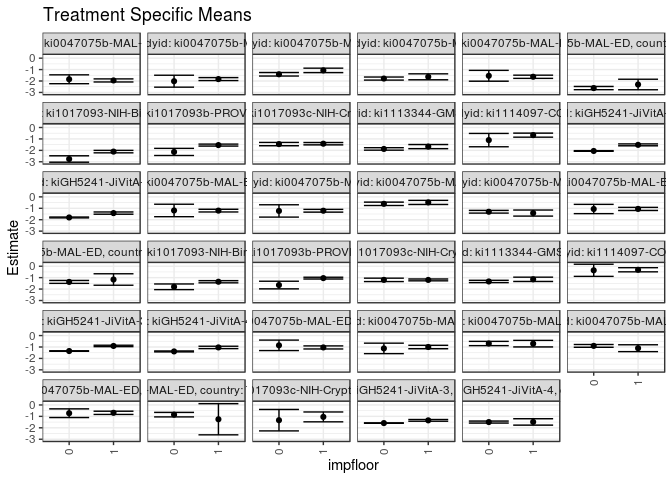

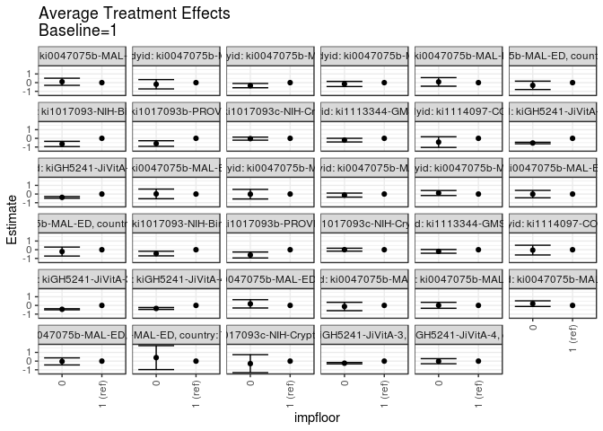

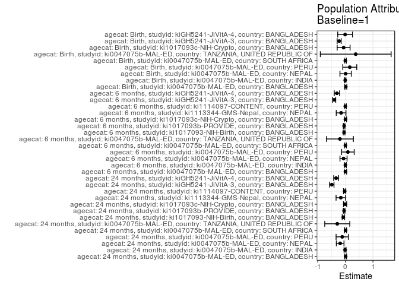

## Results Table

### Parameter: TSM

| agecat | studyid | country | intervention_level | baseline_level | estimate | ci_lower | ci_upper |
| --- | --- | --- | --- | --- | --- | --- | --- |
| Birth | ki0047075b-MAL-ED | BANGLADESH | 1 | NA | -1.0369444 | -1.1700974 | -0.9037915 |
| Birth | ki0047075b-MAL-ED | BANGLADESH | 0 | NA | -0.8550000 | -1.3128744 | -0.3971256 |
| Birth | ki0047075b-MAL-ED | INDIA | 1 | NA | -1.0005525 | -1.1519845 | -0.8491205 |
| Birth | ki0047075b-MAL-ED | INDIA | 0 | NA | -1.1230000 | -1.5812811 | -0.6647189 |
| Birth | ki0047075b-MAL-ED | NEPAL | 1 | NA | -0.7066667 | -0.9943795 | -0.4189538 |
| Birth | ki0047075b-MAL-ED | NEPAL | 0 | NA | -0.6935714 | -0.8813547 | -0.5057882 |
| Birth | ki0047075b-MAL-ED | PERU | 1 | NA | -1.1039286 | -1.4034874 | -0.8043697 |
| Birth | ki0047075b-MAL-ED | PERU | 0 | NA | -0.9008867 | -1.0225223 | -0.7792511 |
| Birth | ki0047075b-MAL-ED | SOUTH AFRICA | 1 | NA | -0.6884264 | -0.8299536 | -0.5468992 |
| Birth | ki0047075b-MAL-ED | SOUTH AFRICA | 0 | NA | -0.7233333 | -1.1027199 | -0.3439468 |
| Birth | ki0047075b-MAL-ED | TANZANIA, UNITED REPUBLIC OF | 1 | NA | -1.2525000 | -2.6166240 | 0.1116240 |
| Birth | ki0047075b-MAL-ED | TANZANIA, UNITED REPUBLIC OF | 0 | NA | -0.8502752 | -1.0483341 | -0.6522163 |
| Birth | ki1017093c-NIH-Crypto | BANGLADESH | 1 | NA | -1.0457143 | -1.4785067 | -0.6129219 |
| Birth | ki1017093c-NIH-Crypto | BANGLADESH | 0 | NA | -1.3350000 | -2.2736100 | -0.3963900 |
| Birth | kiGH5241-JiVitA-3 | BANGLADESH | 1 | NA | -1.3488197 | -1.4245484 | -1.2730910 |
| Birth | kiGH5241-JiVitA-3 | BANGLADESH | 0 | NA | -1.5881392 | -1.6081282 | -1.5681503 |
| Birth | kiGH5241-JiVitA-4 | BANGLADESH | 1 | NA | -1.4867606 | -1.7672692 | -1.2062519 |
| Birth | kiGH5241-JiVitA-4 | BANGLADESH | 0 | NA | -1.4986951 | -1.5864774 | -1.4109127 |
| 6 months | ki0047075b-MAL-ED | BANGLADESH | 1 | NA | -1.2044570 | -1.3236193 | -1.0852948 |
| 6 months | ki0047075b-MAL-ED | BANGLADESH | 0 | NA | -1.1907018 | -1.7345776 | -0.6468259 |
| 6 months | ki0047075b-MAL-ED | INDIA | 1 | NA | -1.2149091 | -1.3361052 | -1.0937130 |
| 6 months | ki0047075b-MAL-ED | INDIA | 0 | NA | -1.2311111 | -1.7710565 | -0.6911657 |
| 6 months | ki0047075b-MAL-ED | NEPAL | 1 | NA | -0.4854369 | -0.6653652 | -0.3055085 |
| 6 months | ki0047075b-MAL-ED | NEPAL | 0 | NA | -0.6091270 | -0.7564400 | -0.4618140 |
| 6 months | ki0047075b-MAL-ED | PERU | 1 | NA | -1.4191379 | -1.6849392 | -1.1533367 |
| 6 months | ki0047075b-MAL-ED | PERU | 0 | NA | -1.3030975 | -1.4213205 | -1.1848745 |
| 6 months | ki0047075b-MAL-ED | SOUTH AFRICA | 1 | NA | -1.0542249 | -1.1907103 | -0.9177395 |
| 6 months | ki0047075b-MAL-ED | SOUTH AFRICA | 0 | NA | -1.0620000 | -1.4685167 | -0.6554833 |
| 6 months | ki0047075b-MAL-ED | TANZANIA, UNITED REPUBLIC OF | 1 | NA | -1.1627381 | -1.6643920 | -0.6610842 |
| 6 months | ki0047075b-MAL-ED | TANZANIA, UNITED REPUBLIC OF | 0 | NA | -1.3733838 | -1.5001316 | -1.2466360 |
| 6 months | ki1017093-NIH-Birth | BANGLADESH | 1 | NA | -1.3581150 | -1.4521493 | -1.2640806 |
| 6 months | ki1017093-NIH-Birth | BANGLADESH | 0 | NA | -1.8004023 | -2.0487867 | -1.5520179 |
| 6 months | ki1017093b-PROVIDE | BANGLADESH | 1 | NA | -1.0413389 | -1.1181192 | -0.9645586 |
| 6 months | ki1017093b-PROVIDE | BANGLADESH | 0 | NA | -1.6477273 | -1.9819520 | -1.3135026 |
| 6 months | ki1017093c-NIH-Crypto | BANGLADESH | 1 | NA | -1.1996182 | -1.2809541 | -1.1182824 |
| 6 months | ki1017093c-NIH-Crypto | BANGLADESH | 0 | NA | -1.1958427 | -1.3444387 | -1.0472467 |
| 6 months | ki1113344-GMS-Nepal | NEPAL | 1 | NA | -1.1451068 | -1.3342599 | -0.9559538 |
| 6 months | ki1113344-GMS-Nepal | NEPAL | 0 | NA | -1.3339991 | -1.4341992 | -1.2337989 |
| 6 months | ki1114097-CONTENT | PERU | 1 | NA | -0.3109834 | -0.4922009 | -0.1297659 |
| 6 months | ki1114097-CONTENT | PERU | 0 | NA | -0.3561071 | -0.8879331 | 0.1757188 |
| 6 months | kiGH5241-JiVitA-3 | BANGLADESH | 1 | NA | -0.9061911 | -0.9657383 | -0.8466439 |
| 6 months | kiGH5241-JiVitA-3 | BANGLADESH | 0 | NA | -1.3524360 | -1.3756750 | -1.3291970 |
| 6 months | kiGH5241-JiVitA-4 | BANGLADESH | 1 | NA | -1.0357458 | -1.1413734 | -0.9301181 |
| 6 months | kiGH5241-JiVitA-4 | BANGLADESH | 0 | NA | -1.3869745 | -1.4252487 | -1.3487003 |
| 24 months | ki0047075b-MAL-ED | BANGLADESH | 1 | NA | -1.9513077 | -2.0840654 | -1.8185500 |
| 24 months | ki0047075b-MAL-ED | BANGLADESH | 0 | NA | -1.8491176 | -2.2363904 | -1.4618449 |
| 24 months | ki0047075b-MAL-ED | INDIA | 1 | NA | -1.8335377 | -1.9631812 | -1.7038943 |
| 24 months | ki0047075b-MAL-ED | INDIA | 0 | NA | -2.0193333 | -2.5422918 | -1.4963749 |
| 24 months | ki0047075b-MAL-ED | NEPAL | 1 | NA | -1.0718878 | -1.2645624 | -0.8792131 |
| 24 months | ki0047075b-MAL-ED | NEPAL | 0 | NA | -1.4132520 | -1.5663867 | -1.2601174 |
| 24 months | ki0047075b-MAL-ED | PERU | 1 | NA | -1.6346939 | -1.8954000 | -1.3739877 |
| 24 months | ki0047075b-MAL-ED | PERU | 0 | NA | -1.7873026 | -1.9220673 | -1.6525380 |
| 24 months | ki0047075b-MAL-ED | SOUTH AFRICA | 1 | NA | -1.6292955 | -1.7703751 | -1.4882158 |
| 24 months | ki0047075b-MAL-ED | SOUTH AFRICA | 0 | NA | -1.5438889 | -2.0180717 | -1.0697061 |
| 24 months | ki0047075b-MAL-ED | TANZANIA, UNITED REPUBLIC OF | 1 | NA | -2.3083333 | -2.7686608 | -1.8480058 |
| 24 months | ki0047075b-MAL-ED | TANZANIA, UNITED REPUBLIC OF | 0 | NA | -2.6208750 | -2.7615309 | -2.4802191 |
| 24 months | ki1017093-NIH-Birth | BANGLADESH | 1 | NA | -2.1099801 | -2.2183180 | -2.0016422 |
| 24 months | ki1017093-NIH-Birth | BANGLADESH | 0 | NA | -2.7561667 | -3.0363741 | -2.4759593 |
| 24 months | ki1017093b-PROVIDE | BANGLADESH | 1 | NA | -1.5393985 | -1.6245892 | -1.4542078 |
| 24 months | ki1017093b-PROVIDE | BANGLADESH | 0 | NA | -2.1384444 | -2.4495572 | -1.8273317 |
| 24 months | ki1017093c-NIH-Crypto | BANGLADESH | 1 | NA | -1.4183237 | -1.5203326 | -1.3163148 |
| 24 months | ki1017093c-NIH-Crypto | BANGLADESH | 0 | NA | -1.4526190 | -1.5965033 | -1.3087348 |
| 24 months | ki1113344-GMS-Nepal | NEPAL | 1 | NA | -1.6716435 | -1.8527543 | -1.4905327 |
| 24 months | ki1113344-GMS-Nepal | NEPAL | 0 | NA | -1.8768797 | -1.9843917 | -1.7693676 |
| 24 months | ki1114097-CONTENT | PERU | 1 | NA | -0.6698377 | -0.8473387 | -0.4923366 |
| 24 months | ki1114097-CONTENT | PERU | 0 | NA | -1.1025000 | -1.6874524 | -0.5175476 |
| 24 months | kiGH5241-JiVitA-3 | BANGLADESH | 1 | NA | -1.5180415 | -1.6010537 | -1.4350294 |
| 24 months | kiGH5241-JiVitA-3 | BANGLADESH | 0 | NA | -2.0544499 | -2.0823909 | -2.0265089 |
| 24 months | kiGH5241-JiVitA-4 | BANGLADESH | 1 | NA | -1.4207597 | -1.5178790 | -1.3236405 |
| 24 months | kiGH5241-JiVitA-4 | BANGLADESH | 0 | NA | -1.8035766 | -1.8395646 | -1.7675885 |

### Parameter: E(Y)

| agecat | studyid | country | intervention_level | baseline_level | estimate | ci_lower | ci_upper |
| --- | --- | --- | --- | --- | --- | --- | --- |
| Birth | ki0047075b-MAL-ED | BANGLADESH | NA | NA | -1.0229487 | -1.1509575 | -0.8949400 |
| Birth | ki0047075b-MAL-ED | INDIA | NA | NA | -1.0069634 | -1.1525107 | -0.8614160 |
| Birth | ki0047075b-MAL-ED | NEPAL | NA | NA | -0.6988415 | -0.8600838 | -0.5375991 |
| Birth | ki0047075b-MAL-ED | PERU | NA | NA | -0.9447876 | -1.0604945 | -0.8290808 |
| Birth | ki0047075b-MAL-ED | SOUTH AFRICA | NA | NA | -0.6917890 | -0.8248091 | -0.5587689 |
| Birth | ki0047075b-MAL-ED | TANZANIA, UNITED REPUBLIC OF | NA | NA | -0.8777778 | -1.0853531 | -0.6702024 |
| Birth | ki1017093c-NIH-Crypto | BANGLADESH | NA | NA | -1.1100000 | -1.5086894 | -0.7113106 |
| Birth | kiGH5241-JiVitA-3 | BANGLADESH | NA | NA | -1.5749762 | -1.5947643 | -1.5551882 |
| Birth | kiGH5241-JiVitA-4 | BANGLADESH | NA | NA | -1.4976642 | -1.5817349 | -1.4135935 |
| 6 months | ki0047075b-MAL-ED | BANGLADESH | NA | NA | -1.2033681 | -1.3212429 | -1.0854932 |
| 6 months | ki0047075b-MAL-ED | INDIA | NA | NA | -1.2159433 | -1.3345235 | -1.0973630 |
| 6 months | ki0047075b-MAL-ED | NEPAL | NA | NA | -0.5534934 | -0.6683107 | -0.4386762 |
| 6 months | ki0047075b-MAL-ED | PERU | NA | NA | -1.3280247 | -1.4371552 | -1.2188942 |
| 6 months | ki0047075b-MAL-ED | SOUTH AFRICA | NA | NA | -1.0548494 | -1.1845497 | -0.9251491 |
| 6 months | ki0047075b-MAL-ED | TANZANIA, UNITED REPUBLIC OF | NA | NA | -1.3613469 | -1.4843950 | -1.2382988 |
| 6 months | ki1017093-NIH-Birth | BANGLADESH | NA | NA | -1.4060639 | -1.4948910 | -1.3172368 |
| 6 months | ki1017093b-PROVIDE | BANGLADESH | NA | NA | -1.0871041 | -1.1635539 | -1.0106543 |
| 6 months | ki1017093c-NIH-Crypto | BANGLADESH | NA | NA | -1.1986783 | -1.2700937 | -1.1272630 |
| 6 months | ki1113344-GMS-Nepal | NEPAL | NA | NA | -1.3005896 | -1.3898487 | -1.2113304 |
| 6 months | ki1114097-CONTENT | PERU | NA | NA | -0.3139217 | -0.4868486 | -0.1409948 |
| 6 months | kiGH5241-JiVitA-3 | BANGLADESH | NA | NA | -1.3134597 | -1.3365976 | -1.2903219 |
| 6 months | kiGH5241-JiVitA-4 | BANGLADESH | NA | NA | -1.3440174 | -1.3812821 | -1.3067527 |
| 24 months | ki0047075b-MAL-ED | BANGLADESH | NA | NA | -1.9431132 | -2.0691678 | -1.8170586 |
| 24 months | ki0047075b-MAL-ED | INDIA | NA | NA | -1.8458150 | -1.9718703 | -1.7197596 |
| 24 months | ki0047075b-MAL-ED | NEPAL | NA | NA | -1.2618778 | -1.3846215 | -1.1391341 |
| 24 months | ki0047075b-MAL-ED | PERU | NA | NA | -1.7500995 | -1.8705474 | -1.6296516 |
| 24 months | ki0047075b-MAL-ED | SOUTH AFRICA | NA | NA | -1.6228361 | -1.7581177 | -1.4875546 |
| 24 months | ki0047075b-MAL-ED | TANZANIA, UNITED REPUBLIC OF | NA | NA | -2.6031840 | -2.7387629 | -2.4676050 |
| 24 months | ki1017093-NIH-Birth | BANGLADESH | NA | NA | -2.1856460 | -2.2886758 | -2.0826161 |
| 24 months | ki1017093b-PROVIDE | BANGLADESH | NA | NA | -1.5861179 | -1.6693668 | -1.5028689 |
| 24 months | ki1017093c-NIH-Crypto | BANGLADESH | NA | NA | -1.4295331 | -1.5127726 | -1.3462935 |
| 24 months | ki1113344-GMS-Nepal | NEPAL | NA | NA | -1.8384978 | -1.9325778 | -1.7444179 |
| 24 months | ki1114097-CONTENT | PERU | NA | NA | -0.6962195 | -0.8674103 | -0.5250287 |
| 24 months | kiGH5241-JiVitA-3 | BANGLADESH | NA | NA | -2.0124544 | -2.0401076 | -1.9848012 |
| 24 months | kiGH5241-JiVitA-4 | BANGLADESH | NA | NA | -1.7579225 | -1.7933649 | -1.7224800 |

### Parameter: ATE

| agecat | studyid | country | intervention_level | baseline_level | estimate | ci_lower | ci_upper |
| --- | --- | --- | --- | --- | --- | --- | --- |
| Birth | ki0047075b-MAL-ED | BANGLADESH | 1 | 1 | 0.0000000 | 0.0000000 | 0.0000000 |
| Birth | ki0047075b-MAL-ED | BANGLADESH | 0 | 1 | 0.1819444 | -0.2948980 | 0.6587869 |
| Birth | ki0047075b-MAL-ED | INDIA | 1 | 1 | 0.0000000 | 0.0000000 | 0.0000000 |
| Birth | ki0047075b-MAL-ED | INDIA | 0 | 1 | -0.1224475 | -0.6050998 | 0.3602047 |
| Birth | ki0047075b-MAL-ED | NEPAL | 1 | 1 | 0.0000000 | 0.0000000 | 0.0000000 |
| Birth | ki0047075b-MAL-ED | NEPAL | 0 | 1 | 0.0130952 | -0.3304761 | 0.3566665 |
| Birth | ki0047075b-MAL-ED | PERU | 1 | 1 | 0.0000000 | 0.0000000 | 0.0000000 |
| Birth | ki0047075b-MAL-ED | PERU | 0 | 1 | 0.2030419 | -0.1202703 | 0.5263540 |
| Birth | ki0047075b-MAL-ED | SOUTH AFRICA | 1 | 1 | 0.0000000 | 0.0000000 | 0.0000000 |
| Birth | ki0047075b-MAL-ED | SOUTH AFRICA | 0 | 1 | -0.0349069 | -0.4398318 | 0.3700179 |
| Birth | ki0047075b-MAL-ED | TANZANIA, UNITED REPUBLIC OF | 1 | 1 | 0.0000000 | 0.0000000 | 0.0000000 |
| Birth | ki0047075b-MAL-ED | TANZANIA, UNITED REPUBLIC OF | 0 | 1 | 0.4022248 | -0.9762024 | 1.7806520 |
| Birth | ki1017093c-NIH-Crypto | BANGLADESH | 1 | 1 | 0.0000000 | 0.0000000 | 0.0000000 |
| Birth | ki1017093c-NIH-Crypto | BANGLADESH | 0 | 1 | -0.2892857 | -1.3228707 | 0.7442993 |
| Birth | kiGH5241-JiVitA-3 | BANGLADESH | 1 | 1 | 0.0000000 | 0.0000000 | 0.0000000 |
| Birth | kiGH5241-JiVitA-3 | BANGLADESH | 0 | 1 | -0.2393195 | -0.3162011 | -0.1624380 |
| Birth | kiGH5241-JiVitA-4 | BANGLADESH | 1 | 1 | 0.0000000 | 0.0000000 | 0.0000000 |
| Birth | kiGH5241-JiVitA-4 | BANGLADESH | 0 | 1 | -0.0119345 | -0.3047389 | 0.2808699 |
| 6 months | ki0047075b-MAL-ED | BANGLADESH | 1 | 1 | 0.0000000 | 0.0000000 | 0.0000000 |
| 6 months | ki0047075b-MAL-ED | BANGLADESH | 0 | 1 | 0.0137553 | -0.5430217 | 0.5705322 |
| 6 months | ki0047075b-MAL-ED | INDIA | 1 | 1 | 0.0000000 | 0.0000000 | 0.0000000 |
| 6 months | ki0047075b-MAL-ED | INDIA | 0 | 1 | -0.0162020 | -0.5695821 | 0.5371781 |
| 6 months | ki0047075b-MAL-ED | NEPAL | 1 | 1 | 0.0000000 | 0.0000000 | 0.0000000 |
| 6 months | ki0047075b-MAL-ED | NEPAL | 0 | 1 | -0.1236901 | -0.3562311 | 0.1088509 |
| 6 months | ki0047075b-MAL-ED | PERU | 1 | 1 | 0.0000000 | 0.0000000 | 0.0000000 |
| 6 months | ki0047075b-MAL-ED | PERU | 0 | 1 | 0.1160404 | -0.1748667 | 0.4069476 |
| 6 months | ki0047075b-MAL-ED | SOUTH AFRICA | 1 | 1 | 0.0000000 | 0.0000000 | 0.0000000 |
| 6 months | ki0047075b-MAL-ED | SOUTH AFRICA | 0 | 1 | -0.0077751 | -0.4365922 | 0.4210420 |
| 6 months | ki0047075b-MAL-ED | TANZANIA, UNITED REPUBLIC OF | 1 | 1 | 0.0000000 | 0.0000000 | 0.0000000 |
| 6 months | ki0047075b-MAL-ED | TANZANIA, UNITED REPUBLIC OF | 0 | 1 | -0.2106457 | -0.7280640 | 0.3067725 |
| 6 months | ki1017093-NIH-Birth | BANGLADESH | 1 | 1 | 0.0000000 | 0.0000000 | 0.0000000 |
| 6 months | ki1017093-NIH-Birth | BANGLADESH | 0 | 1 | -0.4422873 | -0.7078758 | -0.1766989 |
| 6 months | ki1017093b-PROVIDE | BANGLADESH | 1 | 1 | 0.0000000 | 0.0000000 | 0.0000000 |
| 6 months | ki1017093b-PROVIDE | BANGLADESH | 0 | 1 | -0.6063884 | -0.9493189 | -0.2634578 |
| 6 months | ki1017093c-NIH-Crypto | BANGLADESH | 1 | 1 | 0.0000000 | 0.0000000 | 0.0000000 |
| 6 months | ki1017093c-NIH-Crypto | BANGLADESH | 0 | 1 | 0.0037756 | -0.1656243 | 0.1731754 |
| 6 months | ki1113344-GMS-Nepal | NEPAL | 1 | 1 | 0.0000000 | 0.0000000 | 0.0000000 |
| 6 months | ki1113344-GMS-Nepal | NEPAL | 0 | 1 | -0.1888922 | -0.4029458 | 0.0251613 |
| 6 months | ki1114097-CONTENT | PERU | 1 | 1 | 0.0000000 | 0.0000000 | 0.0000000 |
| 6 months | ki1114097-CONTENT | PERU | 0 | 1 | -0.0451237 | -0.6069766 | 0.5167292 |
| 6 months | kiGH5241-JiVitA-3 | BANGLADESH | 1 | 1 | 0.0000000 | 0.0000000 | 0.0000000 |
| 6 months | kiGH5241-JiVitA-3 | BANGLADESH | 0 | 1 | -0.4462449 | -0.5079884 | -0.3845013 |
| 6 months | kiGH5241-JiVitA-4 | BANGLADESH | 1 | 1 | 0.0000000 | 0.0000000 | 0.0000000 |
| 6 months | kiGH5241-JiVitA-4 | BANGLADESH | 0 | 1 | -0.3512287 | -0.4609411 | -0.2415164 |
| 24 months | ki0047075b-MAL-ED | BANGLADESH | 1 | 1 | 0.0000000 | 0.0000000 | 0.0000000 |
| 24 months | ki0047075b-MAL-ED | BANGLADESH | 0 | 1 | 0.1021900 | -0.3072056 | 0.5115857 |
| 24 months | ki0047075b-MAL-ED | INDIA | 1 | 1 | 0.0000000 | 0.0000000 | 0.0000000 |
| 24 months | ki0047075b-MAL-ED | INDIA | 0 | 1 | -0.1857956 | -0.7245840 | 0.3529928 |
| 24 months | ki0047075b-MAL-ED | NEPAL | 1 | 1 | 0.0000000 | 0.0000000 | 0.0000000 |
| 24 months | ki0047075b-MAL-ED | NEPAL | 0 | 1 | -0.3413643 | -0.5874816 | -0.0952469 |
| 24 months | ki0047075b-MAL-ED | PERU | 1 | 1 | 0.0000000 | 0.0000000 | 0.0000000 |
| 24 months | ki0047075b-MAL-ED | PERU | 0 | 1 | -0.1526088 | -0.4460865 | 0.1408690 |
| 24 months | ki0047075b-MAL-ED | SOUTH AFRICA | 1 | 1 | 0.0000000 | 0.0000000 | 0.0000000 |
| 24 months | ki0047075b-MAL-ED | SOUTH AFRICA | 0 | 1 | 0.0854066 | -0.4093184 | 0.5801316 |
| 24 months | ki0047075b-MAL-ED | TANZANIA, UNITED REPUBLIC OF | 1 | 1 | 0.0000000 | 0.0000000 | 0.0000000 |
| 24 months | ki0047075b-MAL-ED | TANZANIA, UNITED REPUBLIC OF | 0 | 1 | -0.3125417 | -0.7938788 | 0.1687955 |
| 24 months | ki1017093-NIH-Birth | BANGLADESH | 1 | 1 | 0.0000000 | 0.0000000 | 0.0000000 |
| 24 months | ki1017093-NIH-Birth | BANGLADESH | 0 | 1 | -0.6461866 | -0.9466084 | -0.3457647 |
| 24 months | ki1017093b-PROVIDE | BANGLADESH | 1 | 1 | 0.0000000 | 0.0000000 | 0.0000000 |
| 24 months | ki1017093b-PROVIDE | BANGLADESH | 0 | 1 | -0.5990459 | -0.9216116 | -0.2764803 |
| 24 months | ki1017093c-NIH-Crypto | BANGLADESH | 1 | 1 | 0.0000000 | 0.0000000 | 0.0000000 |
| 24 months | ki1017093c-NIH-Crypto | BANGLADESH | 0 | 1 | -0.0342953 | -0.2106714 | 0.1420807 |
| 24 months | ki1113344-GMS-Nepal | NEPAL | 1 | 1 | 0.0000000 | 0.0000000 | 0.0000000 |
| 24 months | ki1113344-GMS-Nepal | NEPAL | 0 | 1 | -0.2052361 | -0.4158542 | 0.0053819 |
| 24 months | ki1114097-CONTENT | PERU | 1 | 1 | 0.0000000 | 0.0000000 | 0.0000000 |
| 24 months | ki1114097-CONTENT | PERU | 0 | 1 | -0.4326623 | -1.0439527 | 0.1786280 |
| 24 months | kiGH5241-JiVitA-3 | BANGLADESH | 1 | 1 | 0.0000000 | 0.0000000 | 0.0000000 |
| 24 months | kiGH5241-JiVitA-3 | BANGLADESH | 0 | 1 | -0.5364084 | -0.6229011 | -0.4499156 |
| 24 months | kiGH5241-JiVitA-4 | BANGLADESH | 1 | 1 | 0.0000000 | 0.0000000 | 0.0000000 |
| 24 months | kiGH5241-JiVitA-4 | BANGLADESH | 0 | 1 | -0.3828168 | -0.4831440 | -0.2824897 |

### Parameter: PAR

| agecat | studyid | country | intervention_level | baseline_level | estimate | ci_lower | ci_upper |
| --- | --- | --- | --- | --- | --- | --- | --- |
| Birth | ki0047075b-MAL-ED | BANGLADESH | 1 | NA | 0.0139957 | -0.0232090 | 0.0512004 |
| Birth | ki0047075b-MAL-ED | INDIA | 1 | NA | -0.0064109 | -0.0319765 | 0.0191547 |
| Birth | ki0047075b-MAL-ED | NEPAL | 1 | NA | 0.0078252 | -0.1974820 | 0.2131324 |
| Birth | ki0047075b-MAL-ED | PERU | 1 | NA | 0.1591409 | -0.0944711 | 0.4127529 |
| Birth | ki0047075b-MAL-ED | SOUTH AFRICA | 1 | NA | -0.0033626 | -0.0423932 | 0.0356680 |
| Birth | ki0047075b-MAL-ED | TANZANIA, UNITED REPUBLIC OF | 1 | NA | 0.3747222 | -0.9095864 | 1.6590309 |
| Birth | ki1017093c-NIH-Crypto | BANGLADESH | 1 | NA | -0.0642857 | -0.2985773 | 0.1700058 |
| Birth | kiGH5241-JiVitA-3 | BANGLADESH | 1 | NA | -0.2261565 | -0.2989141 | -0.1533990 |
| Birth | kiGH5241-JiVitA-4 | BANGLADESH | 1 | NA | -0.0109037 | -0.2784156 | 0.2566083 |
| 6 months | ki0047075b-MAL-ED | BANGLADESH | 1 | NA | 0.0010890 | -0.0429917 | 0.0451696 |
| 6 months | ki0047075b-MAL-ED | INDIA | 1 | NA | -0.0010342 | -0.0363600 | 0.0342916 |
| 6 months | ki0047075b-MAL-ED | NEPAL | 1 | NA | -0.0680566 | -0.1962539 | 0.0601408 |
| 6 months | ki0047075b-MAL-ED | PERU | 1 | NA | 0.0911132 | -0.1373737 | 0.3196002 |
| 6 months | ki0047075b-MAL-ED | SOUTH AFRICA | 1 | NA | -0.0006245 | -0.0350686 | 0.0338196 |
| 6 months | ki0047075b-MAL-ED | TANZANIA, UNITED REPUBLIC OF | 1 | NA | -0.1986088 | -0.6864989 | 0.2892812 |
| 6 months | ki1017093-NIH-Birth | BANGLADESH | 1 | NA | -0.0479489 | -0.0790141 | -0.0168838 |
| 6 months | ki1017093b-PROVIDE | BANGLADESH | 1 | NA | -0.0457652 | -0.0747342 | -0.0167962 |
| 6 months | ki1017093c-NIH-Crypto | BANGLADESH | 1 | NA | 0.0009399 | -0.0412325 | 0.0431124 |
| 6 months | ki1113344-GMS-Nepal | NEPAL | 1 | NA | -0.1554827 | -0.3318051 | 0.0208397 |
| 6 months | ki1114097-CONTENT | PERU | 1 | NA | -0.0029383 | -0.0395545 | 0.0336779 |
| 6 months | kiGH5241-JiVitA-3 | BANGLADESH | 1 | NA | -0.4072686 | -0.4638254 | -0.3507118 |
| 6 months | kiGH5241-JiVitA-4 | BANGLADESH | 1 | NA | -0.3082717 | -0.4043493 | -0.2121940 |
| 24 months | ki0047075b-MAL-ED | BANGLADESH | 1 | NA | 0.0081945 | -0.0248473 | 0.0412363 |
| 24 months | ki0047075b-MAL-ED | INDIA | 1 | NA | -0.0122772 | -0.0483850 | 0.0238305 |
| 24 months | ki0047075b-MAL-ED | NEPAL | 1 | NA | -0.1899901 | -0.3287903 | -0.0511898 |
| 24 months | ki0047075b-MAL-ED | PERU | 1 | NA | -0.1154056 | -0.3375248 | 0.1067135 |
| 24 months | ki0047075b-MAL-ED | SOUTH AFRICA | 1 | NA | 0.0064593 | -0.0310671 | 0.0439858 |
| 24 months | ki0047075b-MAL-ED | TANZANIA, UNITED REPUBLIC OF | 1 | NA | -0.2948506 | -0.7490469 | 0.1593456 |
| 24 months | ki1017093-NIH-Birth | BANGLADESH | 1 | NA | -0.0756659 | -0.1159993 | -0.0353325 |
| 24 months | ki1017093b-PROVIDE | BANGLADESH | 1 | NA | -0.0467194 | -0.0750911 | -0.0183476 |
| 24 months | ki1017093c-NIH-Crypto | BANGLADESH | 1 | NA | -0.0112094 | -0.0688744 | 0.0464556 |
| 24 months | ki1113344-GMS-Nepal | NEPAL | 1 | NA | -0.1668543 | -0.3382710 | 0.0045624 |
| 24 months | ki1114097-CONTENT | PERU | 1 | NA | -0.0263818 | -0.0669027 | 0.0141390 |
| 24 months | kiGH5241-JiVitA-3 | BANGLADESH | 1 | NA | -0.4944129 | -0.5749243 | -0.4139014 |
| 24 months | kiGH5241-JiVitA-4 | BANGLADESH | 1 | NA | -0.3371627 | -0.4251436 | -0.2491819 |